# Homework 11

## Question 1: Implementing K-means

K-means is a relatively simple algorithm that we can write ourselves. For Questions 1 and 2, do not use an existing function that performs K-means directly.

Generate 10 observations with two independent standard normal coordinates. Set a random seed and report it. Randomly assign the observations to $K=2$ clusters, making sure neither cluster is empty. Let $C(i)$ denote the cluster assigned to observation $x_i$, and let $m_k$ denote the mean of cluster $k$.

1. Perform one iteration: calculate the cluster means, then assign each observation to its closest mean using Euclidean distance. Report the means and updated assignments, and plot the observations colored by their updated assignments.
2. Write a function that repeats these two steps until the assignments stop changing or a specified maximum number of iterations is reached. Your function should work for a data matrix with any number of variables and a chosen number of clusters $K$. Start from a nonempty assignment to each cluster; if a cluster becomes empty during iteration, keep its previous mean. Recalculate the cluster means from the final assignments before returning them. Return the final assignments, cluster means, and within-cluster sum of squares,

   $$\sum_{k=1}^K\sum_{i:\,C(i)=k}\lVert x_i-m_k\rVert^2.$$
3. Apply your function to the same 10 observations from two different random initial assignments. Report the final plots, cluster means, and within-cluster sums of squares. Do the two runs produce the same grouping and objective value? Explain your findings.

Below is one complete worked solution.

Using seed `7` for the data and seed `8` for the initial assignments, both clusters are nonempty.

```
 [1] 2 2 1 2 1 2 1 2 1 2
```

### a. One iteration

We compute the cluster means, then assign each point to the nearest mean.

```
             x1        x2
[1,] -0.1910422 0.8197240
[2,]  0.3006542 0.7577125
```

```
 [1] 2 1 1 1 1 1 2 1 2 2
```

The cluster means from the initial assignment are

| Cluster | x1 | x2 |
| --- | --- | --- |
| 1 | -0.1910 | 0.8197 |
| 2 | 0.3007 | 0.7577 |

and the updated assignments are

| Observation | Updated_cluster |
| --- | --- |
| x1 | 2 |
| x2 | 1 |
| x3 | 1 |
| x4 | 1 |
| x5 | 1 |
| x6 | 1 |
| x7 | 2 |
| x8 | 1 |
| x9 | 2 |
| x10 | 2 |

The table gives the updated cluster for each observation after this iteration.

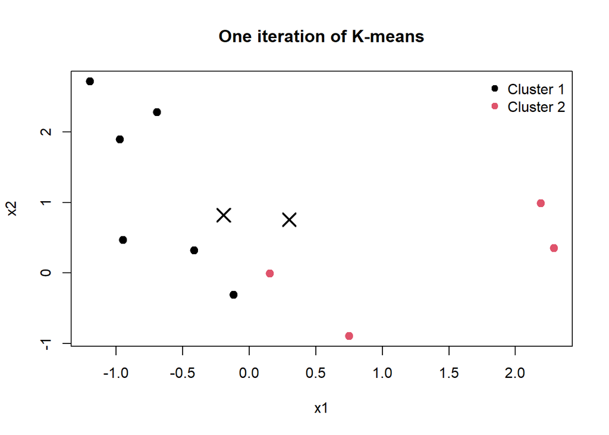

One k-means iteration: observations are colored by the updated cluster assignment after moving each point to the nearest mean.

### b. Repeating the algorithm until convergence

```r
kmeans_manual <- function(X, K, C0, max_iter = 100) {
  C <- as.integer(C0)
  means <- cluster_means(X, C, K)

  for (iter in seq_len(max_iter)) {
    new_C <- closest_mean(X, means)
    new_means <- cluster_means(X, new_C, K)
    empty <- is.na(new_means[, 1])
    new_means[empty, ] <- means[empty, ]

    if (all(new_C == C)) {
      C <- new_C
      means <- new_means
      break
    }
    C <- new_C
    means <- new_means
  }

  final_means <- cluster_means(X, C, K)
  empty <- is.na(final_means[, 1])
  final_means[empty, ] <- means[empty, ]

  sse <- sum(vapply(seq_len(K), function(k) {
    members <- which(C == k)
    if (!length(members)) return(0)
    sum((X[members, , drop = FALSE] -
           matrix(final_means[k, ], length(members), ncol(X), byrow = TRUE))^2)
  }, numeric(1)))

  list(assignments = C, means = final_means, sse = sse)
}
```

### c. Two different starting assignments

These are two different random initial assignments. For this dataset they converge to different groupings and WCSS values, illustrating that K-means can settle at different local optima depending on the starting assignment.

| Run | Cluster_1_mean_x1 | Cluster_1_mean_x2 | Cluster_2_mean_x1 | Cluster_2_mean_x2 | WCSS |
| --- | --- | --- | --- | --- | --- |
| Run 1 | 1.0522 | 0.0278 | -0.8443 | 1.5372 | 12.1315 |
| Run 2 | -0.9523 | 1.8405 | 0.8081 | 0.0772 | 11.9189 |

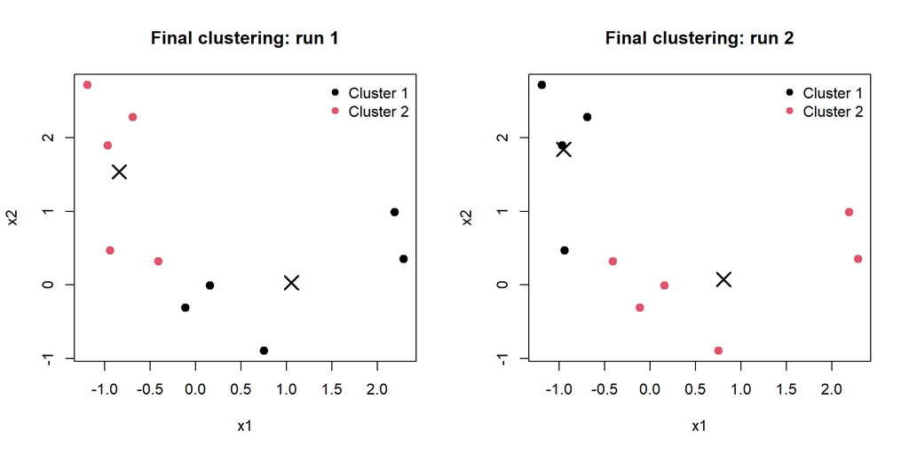

Final cluster assignments from two different random initializations.

The runs produce different groupings and objective values. Cluster labels are arbitrary, but swapping labels alone cannot account for the difference in the two partitions. This illustrates why multiple initial assignments can be useful when applying K-means.

## Question 2: Image color compression

Pick your favorite color image and use your K-means function from Question 1 to cluster its pixels. For computational efficiency, resize the image to no more than $200\times200$ pixels and use its three RGB color channels.

1. Plot the original image and report its dimensions. Transform it into a data matrix with one observation per pixel and three variables: red, green, and blue. Report the dimensions of this matrix.
2. For $K=2,3,5,10$, apply your function to the pixel data. Report the cluster means and within-cluster sum of squares for each $K$. Reconstruct and plot each compressed image by replacing every pixel with its assigned cluster mean. Use the same RGB scale for all fits.
3. Which value of $K$ would you choose for this image? Briefly justify your choice using the reconstructed images and the within-cluster sums of squares.

Below is one complete worked solution for Question 2.

### a. Original image and data matrix

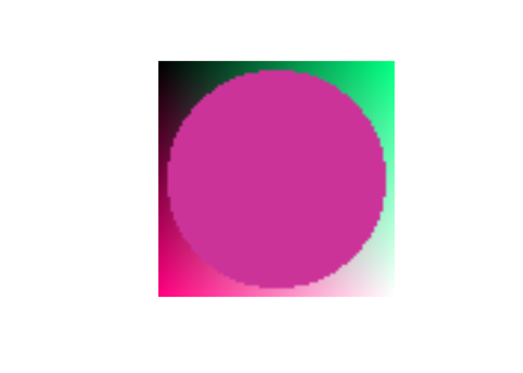

Original test image used for the color-compression exercise.

The image is a generated RGB illustration with dimensions $80 \times 80 \times 3$ (80 rows, 80 columns, and 3 color channels), or 6,400 pixels. Each channel is on the same $[0,1]$ scale. The pixel matrix has one row per pixel and three columns for red, green, and blue:

```
[1] 80 80  3
```

```
[1] 6400    3
```

Thus, the pixel matrix is $6400 \times 3$.

### b. K-means compression for $K = 2, 3, 5, 10$

```
   K      WCSS
1  2 507.31954
2  3 243.68112
3  5  71.49024
4 10  62.23830
```

The cluster centers for each choice of $K$ are:

```
K = 2
             R         G         B
[1,] 0.8125813 0.2548065 0.6144251
[2,] 0.1368161 0.5154786 0.3261473

K = 3
             R         G         B
[1,] 0.8062761 0.1930611 0.5885392
[2,] 0.7644231 0.8901736 0.8272984
[3,] 0.1046749 0.4480398 0.2763573

K = 5
             R          G         B
[1,] 0.1321720 0.86875548 0.5004637
[2,] 0.1250031 0.14269499 0.1338490
[3,] 0.7762970 0.04283295 0.4095650
[4,] 0.8081370 0.20206536 0.5996609
[5,] 0.8602979 0.86882577 0.8645618

K = 10
              R          G         B
 [1,] 0.6941749 0.29391499 0.5624742
 [2,] 0.1273179 0.86639101 0.4968545
 [3,] 0.7762970 0.04283295 0.4095650
 [4,] 0.8135308 0.93323859 0.8733847
 [5,] 0.7009296 0.29438291 0.5648437
 [6,] 0.6979165 0.30283041 0.5657461
 [7,] 0.1252472 0.14193532 0.1335913
 [8,] 0.7012699 0.29377167 0.5655144
 [9,] 0.8070764 0.20055752 0.5989378
[10,] 0.9679865 0.66551369 0.8167501
```

The reconstructed compressed images are shown below.

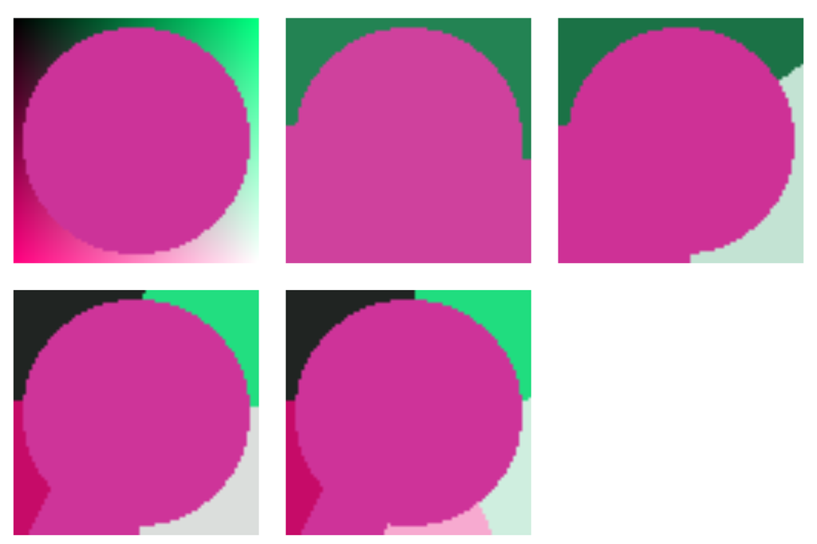

Compressed versions of the original image for K = 2, 3, 5, and 10 using the custom K-means algorithm.

### c. Choice of $K$

The within-cluster sum of squares decreases as $K$ increases:

Within-cluster sum of squares for several values of K.

| K | WCSS |
| --- | --- |
| 2 | 507.3195 |
| 3 | 243.6811 |
| 5 | 71.4902 |
| 10 | 62.2383 |

For this image, I would choose $K = 5$. The $K=2$ and $K=3$ fits are visibly coarse, while $K=5$ recovers the central circle and much of the surrounding gradient. Moving from $K=5$ to $K=10$ further reduces WCSS but adds five colors for a smaller visual improvement. Thus, $K=5$ is a reasonable balance between visual fidelity and palette size.

## Question 3: Hierarchical clustering of cars

The file `data/mtcars.csv` contains 11 numerical variables for 32 cars, including fuel economy, horsepower, and weight. The `car` column gives the model names; use it to label observations, not as a clustering variable. You may use existing hierarchical clustering functions for this question.

1. Standardize each numerical variable to have mean 0 and standard deviation 1. Using Euclidean distance, perform hierarchical clustering with single, complete, and average linkage. Plot the three dendrograms with the car names and compare the results.
2. Choose one linkage method and a number of clusters that you consider reasonable. Report the cluster memberships and a table of cluster means on the original variable scales. Describe the main characteristics of the groups and explain your choice using the dendrogram and table. Briefly explain why standardizing the variables matters for this analysis.

Below is one complete worked solution.

### a. Dendrograms for three linkage methods

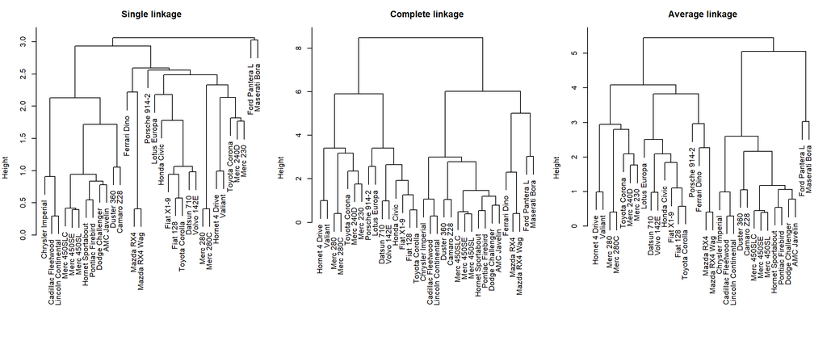

Dendrograms for hierarchical clustering of the standardized mtcars data using Euclidean distance and three linkage methods.

The linkage methods produce different tree shapes. Single linkage joins clusters based on the closest pair and tends to chain observations; at a four-cluster cut its sizes are 1, 1, 12, and 18. Complete linkage uses the farthest pair and gives more compact, balanced groups of sizes 5, 7, 8, and 12. Average linkage uses the average pairwise distance and is intermediate, with sizes 2, 7, 11, and 12. The complete-linkage dendrogram and its four-cluster cut provide a reasonable balance between separation and interpretability.

### b. Final clustering and group summaries

I choose complete linkage with 4 clusters, which gives a reasonable balance between interpretability and separation.

Car memberships from complete-linkage clustering with four clusters.

| Cluster | Cars |
| --- | --- |
| 1 | Mazda RX4, Mazda RX4 Wag, Ford Pantera L, Ferrari Dino, Maserati Bora |
| 2 | Datsun 710, Fiat 128, Honda Civic, Toyota Corolla, Fiat X1-9, Porsche 914-2, Lotus Europa, Volvo 142E |
| 3 | Hornet 4 Drive, Valiant, Merc 240D, Merc 230, Merc 280, Merc 280C, Toyota Corona |
| 4 | Hornet Sportabout, Duster 360, Merc 450SE, Merc 450SL, Merc 450SLC, Cadillac Fleetwood, Lincoln Continental, Chrysler Imperial, Dodge Challenger, AMC Javelin, Camaro Z28, Pontiac Firebird |

The cluster means on the original variable scales are:

Cluster means on the original (unstandardized) mtcars scales for complete-linkage clustering with 4 clusters.

| Cluster | mpg | cyl | disp | hp | drat | wt | qsec | vs | am | gear | carb |
| --- | --- | --- | --- | --- | --- | --- | --- | --- | --- | --- | --- |
| 1 | 18.500 | 6.800 | 223.400 | 198.800 | 3.836 | 3.001 | 15.616 | 0.000 | 1 | 4.600 | 5.200 |
| 2 | 28.075 | 4.000 | 93.612 | 81.875 | 4.184 | 2.042 | 18.450 | 0.875 | 1 | 4.250 | 1.500 |
| 3 | 20.743 | 5.143 | 175.114 | 102.143 | 3.570 | 3.194 | 19.967 | 1.000 | 0 | 3.571 | 2.143 |
| 4 | 15.050 | 8.000 | 357.617 | 194.167 | 3.121 | 4.104 | 17.143 | 0.000 | 0 | 3.000 | 3.083 |

The cluster means show these main characteristics:

- Cluster 2 is the fuel-efficient compact group: high mpg, low displacement, low horsepower, and low weight.
- Cluster 3 is the mid-sized, moderate-performance group: moderate mpg, moderate engine size and horsepower, and moderate weight.
- Cluster 4 is the large, low-efficiency performance/sedan group: low mpg, high cylinders and displacement, high horsepower, and high weight.
- Cluster 1 combines the two Mazda RX4 models with three high-performance cars; it has relatively high horsepower and lower mpg than the compact and mid-sized groups.

I chose 4 clusters because the complete-linkage dendrogram shows a useful separation into branches, and the cluster means summarize distinct vehicle profiles without creating many tiny groups.

Standardizing the variables matters because the variables in `mtcars` are measured on very different scales. For example, `mpg` is around 10–35, while `disp` and `hp` are much larger and more variable. Without standardization, the distances would be dominated by large-scale variables such as displacement and horsepower instead of the more comparable shapes of the overall vehicle profiles. Standardization makes each variable contribute comparably and ensures that the clustering reflects relative patterns rather than arbitrary units.